# Problem Set 1 – MATH 392

Theodore Dounias

1/25/2018

#### 1.1

1. Population is all high school students, sample is 2000 students, 47% is a statistic.
2. From what I recall the 2000 census was still just basically asking everyone, so the US population is the Population, and 13,9% is a parameter.
3. This only draws a reslt for the 2006-2007 season, so the population is all players in that season, and 78,93 is a parameter. If we were using this season as a sample for all seasons, then it would be a statistic.
4. The Population is all US adults, 1.025 is the sample size, 47% is a statistic.

#### 1.3

1. An experiment, as the researchers involved had input into the environment of the study.
2. - 3. No to b, because no to c. Generally a study needs to be valid and ratifiable. This means that the methods and processes used should be scientificaly rigorous, and that it can be reproduced in a different environment. Here we have one study, on a sample that is significantly smaller than the population, and lacking a relevant control group (people on a normal–for a diabetic at least–diet). Therefore, the study is neither valid or ratifiable at this point, so no conclusions can be safely drawn.

#### 1.5

1. 0,00001

```r
(1 - 0.00001)^2000
```

```
## [1] 0.9801986
```

3. About 69.314 samples must be selected

```r
(1 - 0.00001)^69314
```

```
## [1] 0.5000019
```

#### 2.4

```r
depart <- FlightDelays %>%
  group_by(DepartTime) %>%
  mutate(count = 1) %>%
  summarise(n = sum(count))

depart
```

| DepartTime | n |
| --- | --- |
| 4-8am | 699 |
| 8-Noon | 1053 |
| Noon-4pm | 1048 |
| 4-8pm | 972 |
| 8-Mid | 257 |

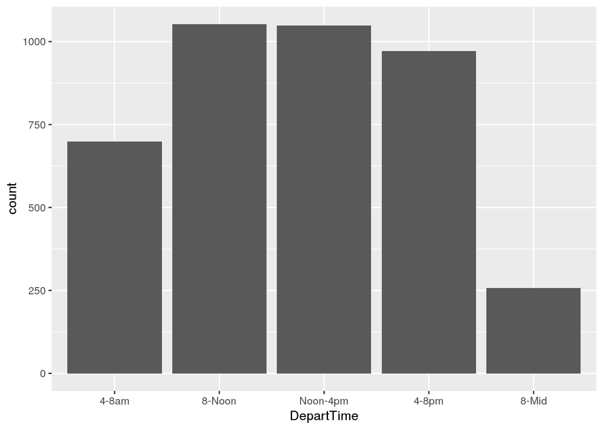

```r
ggplot(FlightDelays, aes(DepartTime)) +
  geom_bar()
```

```r
day_con <- FlightDelays %>%
  select(Day, Delayed30)

day_con$Delayed30 <- as.integer(day_con$Delayed30)

day_con$Delayed30 <- day_con$Delayed30 - 1

day_con <- day_con %>%
  group_by(Day) %>%
  mutate(count = 1) %>%
  summarise(Delayed = sum(Delayed30), Not_Delayed = sum(count) - sum(Delayed30),
            Proportion = sum(Delayed30)/sum(count))

day_con
```

| Day | Delayed | Not_Delayed | Proportion |
| --- | --- | --- | --- |
| Sun | 44 | 507 | 0.07985481 |
| Mon | 61 | 569 | 0.09682540 |
| Tue | 93 | 535 | 0.14808917 |
| Wed | 76 | 488 | 0.13475177 |
| Thu | 132 | 434 | 0.23321555 |
| Fri | 144 | 493 | 0.22605965 |
| Sat | 47 | 406 | 0.10375276 |

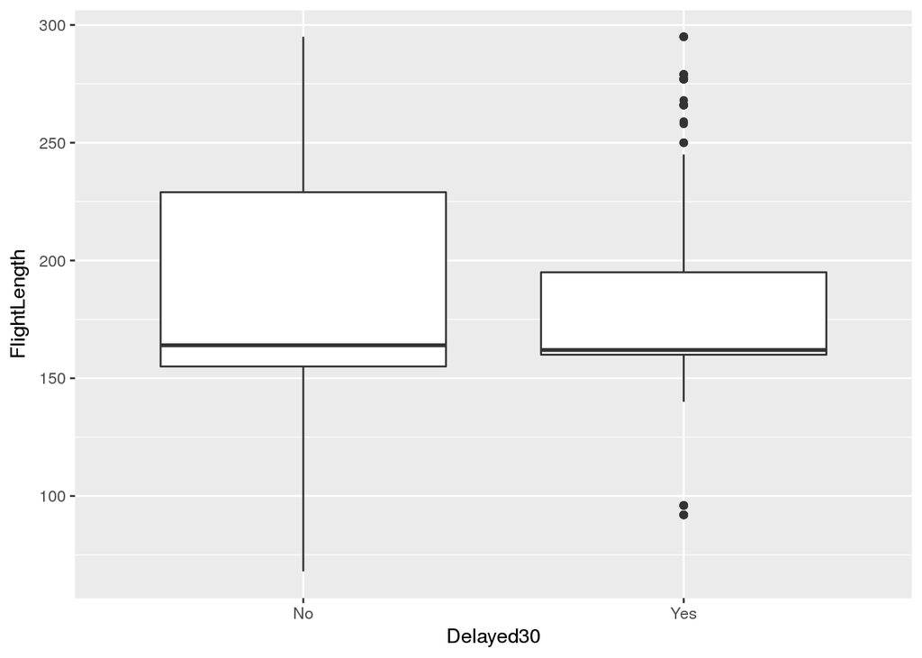

```r
ggplot(FlightDelays) +
  geom_boxplot(aes(y = FlightLength, x = Delayed30))
```

#### 2.8

1. Integrating by parts we get:
   $$E(X) = \int \lambda x e^{-\lambda x} dx = -x e^{-\lambda x} \Big|_{0}^{\infty} + \int_{0}^{\infty} e^{-\lambda x}dx = \frac{1}{\lambda}$$

Here we can use the integral definition of quantile to get:
$$\int_{0}^{a} \lambda e^{-\lambda x} dx = p \Rightarrow 1+e^{-\lambda a} = p \Rightarrow a = \frac{-ln(1 - p)}{\lambda}$$

So the quantiles are $\frac{ln(\frac{4}{3})}{\lambda}$ and $\frac{ln(4)}{\lambda}$